# HW1_Valentine

#### * Feel free to use summary stats, tables, figures. Don’t worry about high production values.

We can also produce a histogram

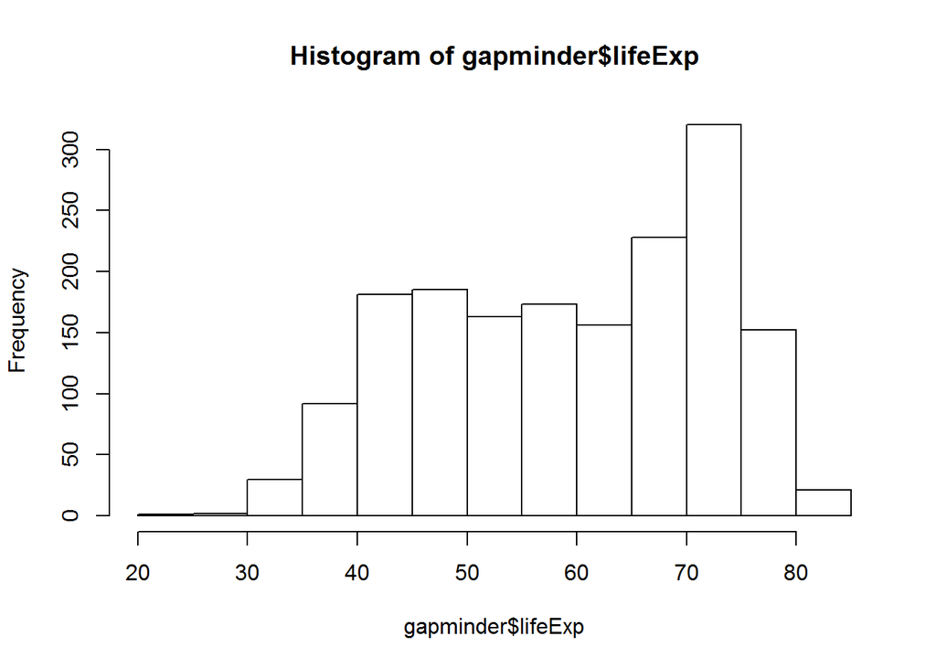

```r
hist(gapminder$lifeExp)
```

This histogram confirms that our data skews left.

### Part D - Getting down to business

### Tasks & Companion Graphs

#### 1. Get the maximum and minimum of GDP* per capita for all continents.

*Note: As suggested in the instructions, I am substituting quantifiable variables. I am switching out gdp for life expectancy.

```r
library(dplyr);library(knitr)

gapminder %>% group_by(continent) %>% summarise(min = min(lifeExp),max = max(lifeExp))
```

```
## Source: local data frame [5 x 3]
##
##   continent    min    max
## 1    Africa 23.599 76.442
## 2  Americas 37.579 80.653
## 3      Asia 28.801 82.603
## 4    Europe 43.585 81.757
## 5   Oceania 69.120 81.235
```

```r
#with kable function
kable(gapminder %>% group_by(continent) %>% summarise(min = min(lifeExp),max = max(lifeExp)))
```

| continent | min | max |
| --- | --- | --- |
| Africa | 23.599 | 76.442 |
| Americas | 37.579 | 80.653 |
| Asia | 28.801 | 82.603 |
| Europe | 43.585 | 81.757 |
| Oceania | 69.120 | 81.235 |

we can also use the kable function to print a nicer formatted verison to screen

```r
library(dplyr);library(knitr)

kable(gapminder %>% group_by(continent) %>% summarise(min = min(lifeExp),max = max(lifeExp)))
```

| continent | min | max |
| --- | --- | --- |
| Africa | 23.599 | 76.442 |
| Americas | 37.579 | 80.653 |
| Asia | 28.801 | 82.603 |
| Europe | 43.585 | 81.757 |
| Oceania | 69.120 | 81.235 |

#### 2. Look at the spread of GDP per capita within the continents.

*Note: As suggested in the instructions, I am substituting quantifiable variables. I am switching out gdp for life expectancy.

```r
gapminder %>% group_by(continent) %>% summarise(min = min(lifeExp), max = max(lifeExp),range = max - min)
```

```
## Source: local data frame [5 x 4]
##
##   continent    min    max  range
## 1    Africa 23.599 76.442 52.843
## 2  Americas 37.579 80.653 43.074
## 3      Asia 28.801 82.603 53.802
## 4    Europe 43.585 81.757 38.172
## 5   Oceania 69.120 81.235 12.115
```

Note: had to complete install.packages(“ggplot2”) to complete the following table

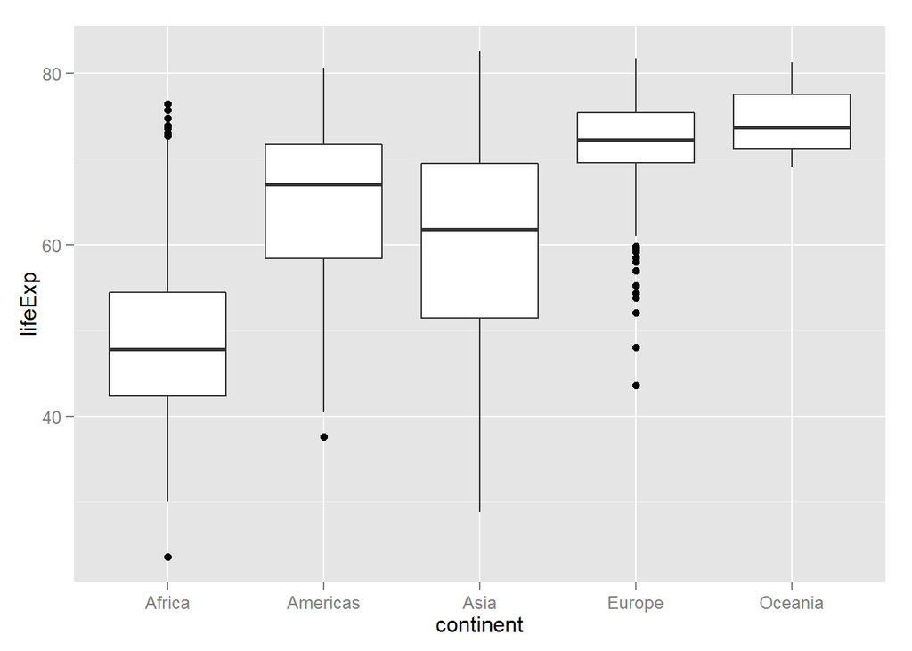

```r
library(ggplot2)
ggplot(data = gapminder,aes(group=continent,y=lifeExp,x=continent)) + geom_boxplot()
```

#### 3. Compute a trimmed mean of life expectancy for different years. Or a weighted mean, weighting by population. Just try something other than the plain vanilla mean.

Note: In the instructions, it is suggested 5% is too much, so I am trimming by 2.5%

```r
gapminder %>% group_by(year) %>% summarise(trimmed.mean = mean(lifeExp,trim=0.025))
```

```
## Source: local data frame [12 x 2]
##
##    year trimmed.mean
## 1  1952     48.97115
## 2  1957     51.47243
## 3  1962     53.62745
## 4  1967     55.73994
## 5  1972     57.75320
## 6  1977     59.75404
## 7  1982     61.68800
## 8  1987     63.39814
## 9  1992     64.50653
## 10 1997     65.26310
## 11 2002     65.91455
## 12 2007     67.23829
```

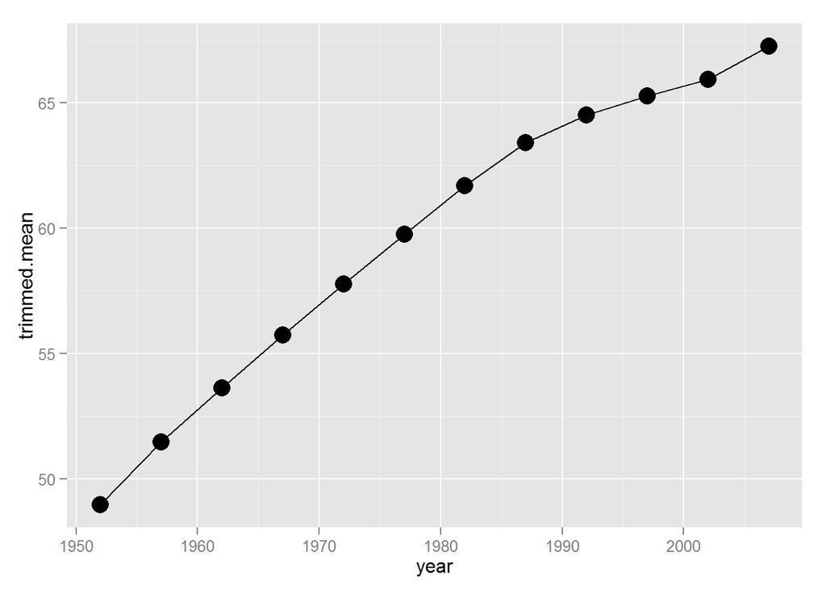

```r
trimmed.lifexp.means.by.year <- gapminder %>% group_by(year) %>% summarise(trimmed.mean = mean(lifeExp,trim=0.025))
ggplot(data=trimmed.lifexp.means.by.year) + geom_path(aes(x=year,y=trimmed.mean)) + geom_point(aes(x=year,y=trimmed.mean),size=5)
```

#### 4. How is life expectancy changing over time on different continents?

Note: had to complete install.packages(“tidyr”) to complete the following table

```r
library(tidyr)
mean.lifeExp.longfile = gapminder %>% group_by(continent,year) %>% summarise(mean = mean(lifeExp))
#As suggested by key file, we round mean to 2 digits so it prints nicely
mean.lifeExp.longfile %>% mutate(mean = round(mean,2)) %>% spread(year,mean)
```

```
## Source: local data frame [5 x 13]
##
##   continent  1952  1957  1962  1967  1972  1977  1982  1987  1992  1997
## 1    Africa 39.14 41.27 43.32 45.33 47.45 49.58 51.59 53.34 53.63 53.60
## 2  Americas 53.28 55.96 58.40 60.41 62.39 64.39 66.23 68.09 69.57 71.15
## 3      Asia 46.31 49.32 51.56 54.66 57.32 59.61 62.62 64.85 66.54 68.02
## 4    Europe 64.41 66.70 68.54 69.74 70.78 71.94 72.81 73.64 74.44 75.51
## 5   Oceania 69.25 70.30 71.09 71.31 71.91 72.85 74.29 75.32 76.94 78.19
## Variables not shown: 2002 (dbl), 2007 (dbl)
```

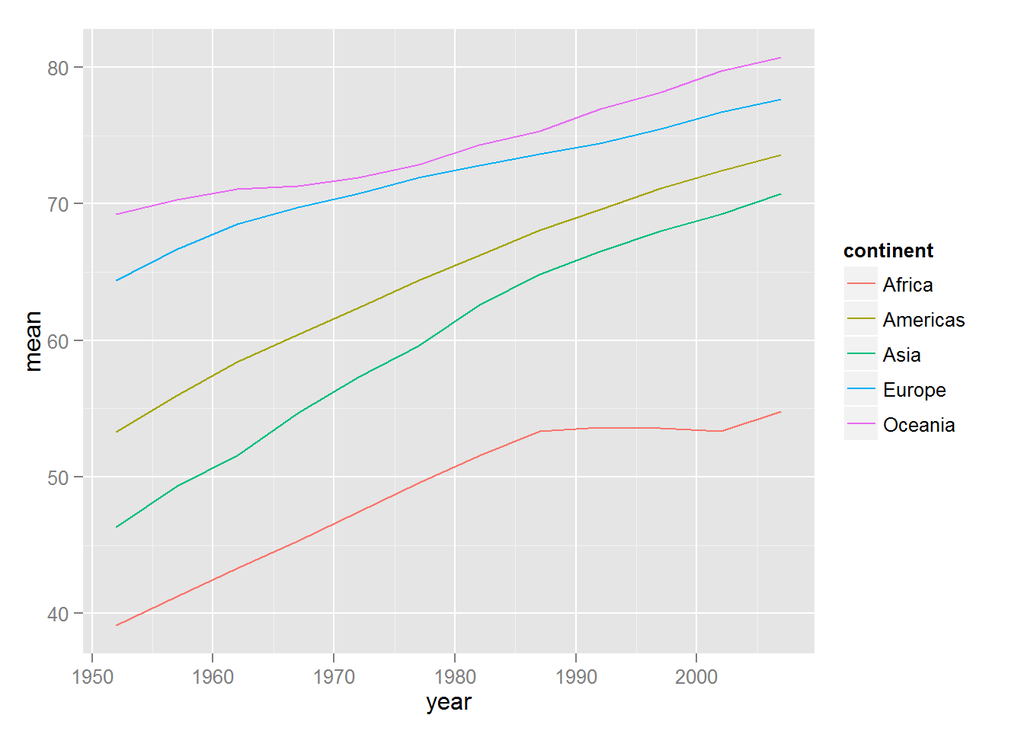

```r
lifexp.mean.by.year.continent <- gapminder %>% group_by(continent,year) %>% summarise(mean = mean(lifeExp))
ggplot(data=lifexp.mean.by.year.continent) + geom_line(aes(x=year,y=mean,color=continent))
```

#### 5. Report the absolute and/or relative abundance of countries with low life expectancy over time by continent: Compute some measure of worldwide life expectancy - you decide - a mean or median or some other quantile or perhaps your current age. The determine how many countries on each continent have a life expectancy less than this benchmark, for each year.

We can define low-life expectancy as at least 1 standard deviation below the mean for that year.

```r
life.exp.table <- gapminder %>% group_by(year) %>% mutate(year.mean = mean(lifeExp),year.sd = sd(lifeExp),low.lifeExp = ifelse(lifeExp < year.mean - year.sd,1,0))

summary(life.exp.table)
```

```
##         country          year           pop               continent
##  Afghanistan:  12   Min.   :1952   Min.   :6.001e+04   Africa  :624
##  Albania    :  12   1st Qu.:1966   1st Qu.:2.794e+06   Americas:300
##  Algeria    :  12   Median :1980   Median :7.024e+06   Asia    :396
##  Angola     :  12   Mean   :1980   Mean   :2.960e+07   Europe  :360
##  Argentina  :  12   3rd Qu.:1993   3rd Qu.:1.959e+07   Oceania : 24
##  Australia  :  12   Max.   :2007   Max.   :1.319e+09
##  (Other)    :1632
##     lifeExp        gdpPercap          year.mean        year.sd
##  Min.   :23.60   Min.   :   241.2   Min.   :49.06   Min.   :10.56
##  1st Qu.:48.20   1st Qu.:  1202.1   1st Qu.:55.16   1st Qu.:11.23
##  Median :60.71   Median :  3531.8   Median :60.55   Median :11.64
##  Mean   :59.47   Mean   :  7215.3   Mean   :59.47   Mean   :11.61
##  3rd Qu.:70.85   3rd Qu.:  9325.5   3rd Qu.:64.37   3rd Qu.:12.13
##  Max.   :82.60   Max.   :113523.1   Max.   :67.01   Max.   :12.28
##
##   low.lifeExp
##  Min.   :0.0000
##  1st Qu.:0.0000
##  Median :0.0000
##  Mean   :0.1972
##  3rd Qu.:0.0000
##  Max.   :1.0000
##
```

```r
low.lifeExp.by.continent = life.exp.table %>% group_by(continent,year) %>% summarise(prop.low.lifeExp = round(mean(low.lifeExp),2))

summary(low.lifeExp.by.continent)
```

```
##     continent       year      prop.low.lifeExp
##  Africa  :12   Min.   :1952   Min.   :0.0000
##  Americas:12   1st Qu.:1966   1st Qu.:0.0000
##  Asia    :12   Median :1980   Median :0.0000
##  Europe  :12   Mean   :1980   Mean   :0.1142
##  Oceania :12   3rd Qu.:1993   3rd Qu.:0.1200
##                Max.   :2007   Max.   :0.6000
```

```r
low.lifeExp.by.continent %>% spread(key = year, value = prop.low.lifeExp)
```

```
## Source: local data frame [5 x 13]
##
##   continent 1952 1957 1962 1967 1972 1977 1982 1987 1992 1997 2002 2007
## 1    Africa 0.33 0.37 0.42 0.44 0.48 0.46 0.50 0.54 0.52 0.56 0.60 0.58
## 2  Americas 0.00 0.00 0.00 0.00 0.00 0.00 0.00 0.00 0.00 0.00 0.00 0.00
## 3      Asia 0.12 0.09 0.12 0.12 0.15 0.15 0.12 0.06 0.03 0.03 0.03 0.03
## 4    Europe 0.00 0.00 0.00 0.00 0.00 0.00 0.00 0.00 0.00 0.00 0.00 0.00
## 5   Oceania 0.00 0.00 0.00 0.00 0.00 0.00 0.00 0.00 0.00 0.00 0.00 0.00
```

We can also use the kable function to print a nicer formatted verison to screen

```r
library(dplyr);library(knitr)

kable(low.lifeExp.by.continent %>% spread(key = year, value = prop.low.lifeExp))
```

| continent | 1952 | 1957 | 1962 | 1967 | 1972 | 1977 | 1982 | 1987 | 1992 | 1997 | 2002 | 2007 |
| --- | --- | --- | --- | --- | --- | --- | --- | --- | --- | --- | --- | --- |
| Africa | 0.33 | 0.37 | 0.42 | 0.44 | 0.48 | 0.46 | 0.50 | 0.54 | 0.52 | 0.56 | 0.60 | 0.58 |
| Americas | 0.00 | 0.00 | 0.00 | 0.00 | 0.00 | 0.00 | 0.00 | 0.00 | 0.00 | 0.00 | 0.00 | 0.00 |
| Asia | 0.12 | 0.09 | 0.12 | 0.12 | 0.15 | 0.15 | 0.12 | 0.06 | 0.03 | 0.03 | 0.03 | 0.03 |
| Europe | 0.00 | 0.00 | 0.00 | 0.00 | 0.00 | 0.00 | 0.00 | 0.00 | 0.00 | 0.00 | 0.00 | 0.00 |
| Oceania | 0.00 | 0.00 | 0.00 | 0.00 | 0.00 | 0.00 | 0.00 | 0.00 | 0.00 | 0.00 | 0.00 | 0.00 |

Now, for the table/graph

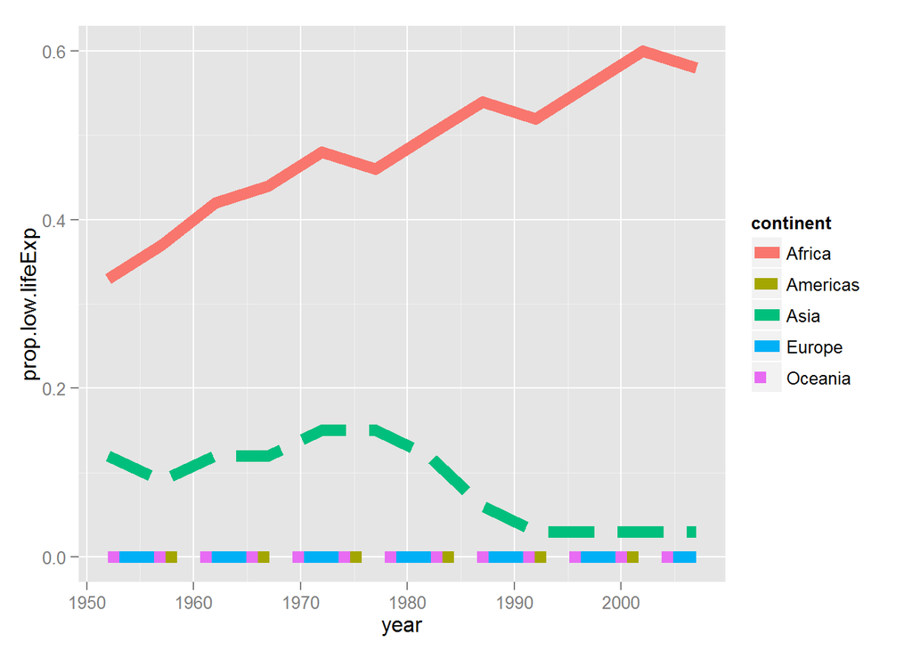

```r
ggplot(data = low.lifeExp.by.continent,aes(x=year,y=prop.low.lifeExp)) + geom_line(aes(color=continent,lty=continent),size=3)
```

#### 6. Find countries with interesting stories. Open-ended and, therefore, hard. Promising but unsuccessful attempts are encouraged. This will generate interesting questions to follow up on in class.

First, I want to look at data from 1997, and I am comparing the two quantifiable variables from this data set (GDP/Life Expectancy) and processing this by country. By doing so, we can “find countries with interesting stories.”

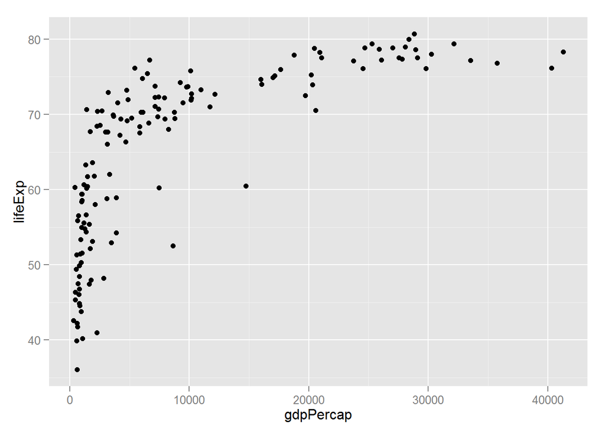

```r
ggplot(gapminder[gapminder$year==1997,],aes(x=gdpPercap,y=lifeExp)) + geom_point(aes(label=country))
```

After viewing the resulting charts, we can identify certain countries overperform in terms of life expectancy based upon GDP per capita. To examine this, I filter for countries with GDP above 35k, then plot country names.:

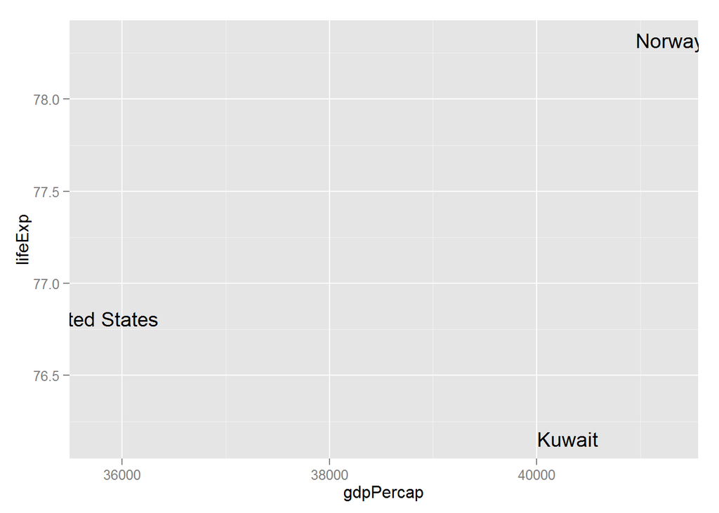

```r
ggplot(gapminder[gapminder$year==1997&gapminder$gdpPercap>35000,],aes(x=gdpPercap,y=lifeExp)) + geom_text(aes(label=country))
```

Once we isolate these countries, we find two nations that may not be a surprise (Norway and the United States) and then one that was not expected (Kuwait). We could speculate that GDP and healthcare are high for the United States and Norway, and perhaps a robust oil/economy in Kuwait has helped it reach this strata.

### Report your process

#### You’re encouraged to reflect on what was hard/easy, problems you solved, helpful tutorials you read, etc. Give credit to your sources, whether it’s a blog post, a fellow student, an online tutorial, etc.

This activity was fun, but largely due to the resources we were provided. Having the key available reduced anxiety over where to start, but then I was free to experiment (changing out quant. variables, looking at different years, looking at high levels of lifeexp/gdp instead of low) and practice using the tools. It also was helpful having a first sit down group meeting with Jon, Emily, and Youkyoung (with the assistance of Tyler) in the graduate lounge.

In general, my method consisting of combining knowledge learned in class, tutorials from r-bloggers.com, reviewing the answer key, and using the ? command to find out more about certain operations.